# INN_Learner_Notebook_Full_code

```python
print("Time taken in seconds: ",end-start)
```

```
Time taken in seconds:  46.0454261302948
```

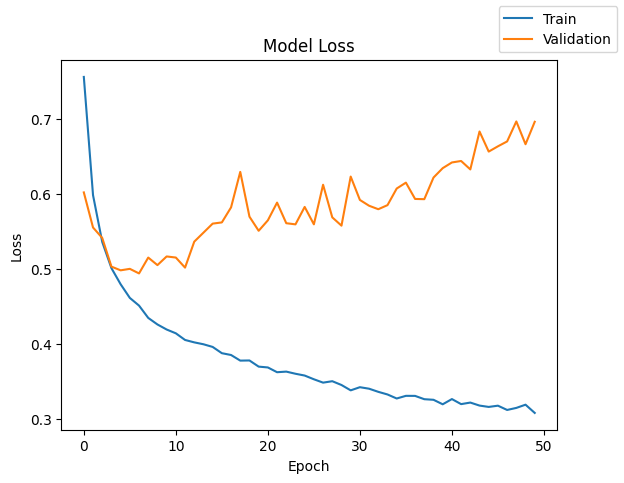

```python
plot(history,'loss')
```

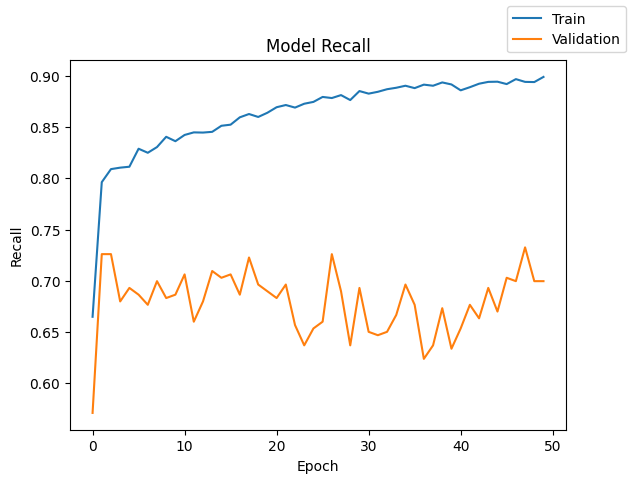

```python
plot(history,'recall')
```

```
(11148, 11)
(11148, 1)
Confusion Matrix - NN with Adam With SMOTE OverSampled Data - train
349/349 ━━━━━━━━━━━━━━━━━━━━ 1s 2ms/step
```

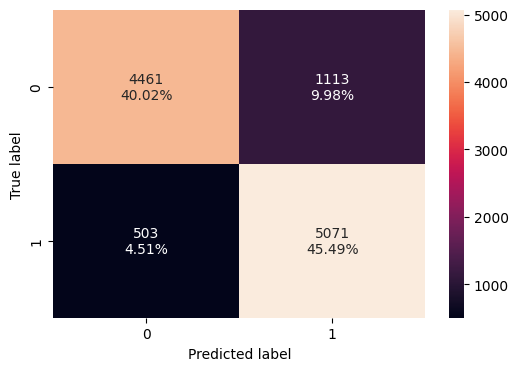

```
              precision    recall  f1-score   support

         0.0       0.90      0.80      0.85      5574
         1.0       0.82      0.91      0.86      5574

    accuracy                           0.86     11148
   macro avg       0.86      0.86      0.85     11148
weighted avg       0.86      0.86      0.85     11148
```

```python
plot_confusion_matrix(model_4, X_train_over, y_train_over, 'train', model_name)
```

```
(1500, 11)
(1500, 1)
Confusion Matrix - NN with Adam With SMOTE OverSampled Data - validation
47/47 ━━━━━━━━━━━━━━━━━━━━ 0s 4ms/step
```

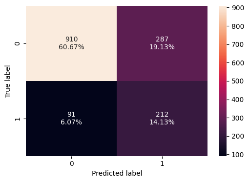

```
              precision    recall  f1-score   support

         0.0       0.91      0.76      0.83      1197
         1.0       0.42      0.70      0.53       303

    accuracy                           0.75      1500
   macro avg       0.67      0.73      0.68      1500
weighted avg       0.81      0.75      0.77      1500
```

```python
plot_confusion_matrix(model_4, X_val, y_val, 'validation', model_name)
```

```python
results.drop([4], inplace=True, errors='ignore')
results.loc[4] = [5,[64,32,16,8,4],["relu","relu","relu","relu","relu"],50,32,"Adam",[0.001, "-"],"xavier","-",history.history["loss"][-1],history.history["val_loss"][-1],history.history["recall"][-1],history.history["val_recall"][-1],round(end-start,2)]
results
```

|  | # hidden layers | # neurons - hidden layer | activation function - hidden layer | # epochs | batch size | optimizer | learning rate, momentum | weight initializer | regularization | train loss | validation loss | train recall | validation recall | time (secs) |
| --- | --- | --- | --- | --- | --- | --- | --- | --- | --- | --- | --- | --- | --- | --- |
| 0 | 2 | [64, 32] | [relu, tanh] | 100 | 50 | sgd | [0.001, -] | xavier | - | 0.353841 | 0.359846 | 0.414446 | 0.432343 | 26.36 |
| 1 | 2 | [64, 32] | [relu, relu] | 50 | 25 | Adam | [0.001, -] | xavier | - | 0.291288 | 0.361662 | 0.572931 | 0.471947 | 25.95 |
| 2 | 5 | [64, 32, 16, 8, 4] | [relu, relu, relu, relu, relu] | 50 | 25 | Adam | [0.001, -] | xavier | - | 0.357890 | 0.356914 | 0.474053 | 0.471947 | 35.99 |
| 3 | 5 | [64, 32, 16, 8, 4] | [relu, relu, relu, relu, relu] | 50 | 32 | sgd | [0.001, -] | xavier | - | 0.530878 | 0.584543 | 0.821313 | 0.699670 | 39.72 |
| 4 | 5 | [64, 32, 16, 8, 4] | [relu, relu, relu, relu, relu] | 50 | 32 | Adam | [0.001, -] | xavier | - | 0.308397 | 0.696688 | 0.899175 | 0.699670 | 46.05 |

```python
eval_metric
```

|  | train-recall | validation-recall | train-f1-score | validation-f1-score | train-precision | validation-precision | train-roc-auc | validation-roc-auc | train-accurecy | validation-accurecy |
| --- | --- | --- | --- | --- | --- | --- | --- | --- | --- | --- |
| NN with SGD | 0.434081 | 0.432343 | 0.545134 | 0.544699 | 0.732544 | 0.735955 | 0.696768 | 0.696539 | 0.852429 | 0.854 |
| NN with Adam | 0.570126 | 0.471947 | 0.656704 | 0.573146 | 0.774286 | 0.729592 | 0.763804 | 0.713835 | 0.878571 | 0.858 |
| NN with Adam With Dropout | 0.508415 | 0.471947 | 0.605175 | 0.576613 | 0.747423 | 0.740933 | 0.732231 | 0.715088 | 0.864857 | 0.86 |
| NN with SGD With SMOTE OverSampled Data | 0.82526 | 0.69967 | 0.813943 | 0.541507 | 0.802932 | 0.441667 | 0.811356 | 0.737888 | 0.811356 | 0.760667 |
| NN with Adam With SMOTE OverSampled Data | 0.90976 | 0.69967 | 0.862562 | 0.528678 | 0.820019 | 0.42485 | 0.855041 | 0.729952 | 0.855041 | 0.748 |

**Observations**

- Loss & Recall Plot
  - The training loss is steadily decreasing, indicating that the model is learning well during the training phase. However, the validation loss increases after a certain point, suggesting potential overfitting.
  - The training recall continues to improve steadily, while validation recall fluctuates and remains lower. This could indicate overfitting, as the model generalizes less effectively on unseen data.
- Evaluation Metrics
  - The model performs well on the oversampled training dataset, achieving high precision, recall, and F1-score. This is expected as SMOTE balances the data and the model learns on it effectively.
  - The validation performance shows a decline in precision, and F1-score. Although recall has remained same leading to a moderate F1-score.
- Points to note
  - **Train vs Validation Gap**: The gap in metrics (e.g., recall, F1-score) between training and validation datasets highlights overfitting and warrants additional steps to improve generalization.

### Neural Network with Balanced Data (by applying SMOTE), Adam Optimizer, and Dropout

```python
tf.keras.backend.clear_session() #Clearing the session.
#Initializing the neural network
model_name = 'NN with Adam With SMOTE OverSampled Data and DropOuts';
batch_size=32
epochs=50
model_5 = Sequential()
input_dimention = X_train.shape[1]
print("Input Dimention:", input_dimention)
# Adding hidden layers with droput ratios
model_5.add(Dense(64, activation='relu', input_dim = input_dimention, kernel_regularizer=tf.keras.regularizers.l2(0.01)))
model_5.add(Dropout(0.3))
model_5.add(Dense(32, activation='relu'))
model_5.add(Dropout(0.2))
model_5.add(Dense(16, activation='relu'))
model_5.add(Dense(8, activation='relu'))
model_5.add(Dropout(0.1))
model_5.add(Dense(4, activation='relu'))
# Adding the output layer
model_5.add(Dense(1, activation = 'sigmoid'))
optimizer = keras.optimizers.Adam(learning_rate=0.001)   # defining Adam as the optimizer to be used
model_5.compile(loss="binary_crossentropy", optimizer=optimizer, metrics=["recall"])
model_5.summary()
```

```
Input Dimention: 11
```

```
Model: "sequential"
```

```
┏━━━━━━━━━━━━━━━━━━━━━━━━━━━━━━━━━━━━━━┳━━━━━━━━━━━━━━━━━━━━━━━━━━━━━┳━━━━━━━━━━━━━━━━━┓
┃ Layer (type)                         ┃ Output Shape                ┃         Param # ┃
┡━━━━━━━━━━━━━━━━━━━━━━━━━━━━━━━━━━━━━━╇━━━━━━━━━━━━━━━━━━━━━━━━━━━━━╇━━━━━━━━━━━━━━━━━┩
│ dense (Dense)                        │ (None, 64)                  │             768 │
├──────────────────────────────────────┼─────────────────────────────┼─────────────────┤
│ dropout (Dropout)                    │ (None, 64)                  │               0 │
├──────────────────────────────────────┼─────────────────────────────┼─────────────────┤
│ dense_1 (Dense)                      │ (None, 32)                  │           2,080 │
├──────────────────────────────────────┼─────────────────────────────┼─────────────────┤
│ dropout_1 (Dropout)                  │ (None, 32)                  │               0 │
├──────────────────────────────────────┼─────────────────────────────┼─────────────────┤
│ dense_2 (Dense)                      │ (None, 16)                  │             528 │
├──────────────────────────────────────┼─────────────────────────────┼─────────────────┤
│ dense_3 (Dense)                      │ (None, 8)                   │             136 │
├──────────────────────────────────────┼─────────────────────────────┼─────────────────┤
│ dropout_2 (Dropout)                  │ (None, 8)                   │               0 │
├──────────────────────────────────────┼─────────────────────────────┼─────────────────┤
│ dense_4 (Dense)                      │ (None, 4)                   │              36 │
├──────────────────────────────────────┼─────────────────────────────┼─────────────────┤
│ dense_5 (Dense)                      │ (None, 1)                   │               5 │
└──────────────────────────────────────┴─────────────────────────────┴─────────────────┘
```

```
 Total params: 3,553 (13.88 KB)
```

```
 Trainable params: 3,553 (13.88 KB)
```

```
 Non-trainable params: 0 (0.00 B)
```

```python
start = time.time()
history = model_5.fit(X_train_over, y_train_over, validation_data=(X_val,y_val) , batch_size=batch_size, epochs=epochs, verbose=1)
end=time.time()
```

```
349/349 ━━━━━━━━━━━━━━━━━━━━ 7s 10ms/step - loss: 0.8044 - recall: 0.3157 - val_loss: 0.6076 - val_recall: 0.7558
349/349 ━━━━━━━━━━━━━━━━━━━━ 1s 2ms/step - loss: 0.6232 - recall: 0.7358 - val_loss: 0.6069 - val_recall: 0.7360
349/349 ━━━━━━━━━━━━━━━━━━━━ 1s 2ms/step - loss: 0.5887 - recall: 0.7357 - val_loss: 0.5772 - val_recall: 0.7129
349/349 ━━━━━━━━━━━━━━━━━━━━ 1s 2ms/step - loss: 0.5782 - recall: 0.7392 - val_loss: 0.5826 - val_recall: 0.7492
349/349 ━━━━━━━━━━━━━━━━━━━━ 1s 2ms/step - loss: 0.5505 - recall: 0.7459 - val_loss: 0.4763 - val_recall: 0.6436
349/349 ━━━━━━━━━━━━━━━━━━━━ 1s 2ms/step - loss: 0.5230 - recall: 0.7244 - val_loss: 0.5209 - val_recall: 0.6931
349/349 ━━━━━━━━━━━━━━━━━━━━ 1s 2ms/step - loss: 0.4860 - recall: 0.7589 - val_loss: 0.4778 - val_recall: 0.7096
349/349 ━━━━━━━━━━━━━━━━━━━━ 1s 2ms/step - loss: 0.4887 - recall: 0.7385 - val_loss: 0.4721 - val_recall: 0.6964
349/349 ━━━━━━━━━━━━━━━━━━━━ 1s 2ms/step - loss: 0.4825 - recall: 0.7401 - val_loss: 0.4976 - val_recall: 0.7261
349/349 ━━━━━━━━━━━━━━━━━━━━ 1s 2ms/step - loss: 0.4676 - recall: 0.7557 - val_loss: 0.4697 - val_recall: 0.7129
349/349 ━━━━━━━━━━━━━━━━━━━━ 1s 2ms/step - loss: 0.4591 - recall: 0.7732 - val_loss: 0.4707 - val_recall: 0.7030
349/349 ━━━━━━━━━━━━━━━━━━━━ 1s 2ms/step - loss: 0.4613 - recall: 0.7552 - val_loss: 0.4725 - val_recall: 0.6832
349/349 ━━━━━━━━━━━━━━━━━━━━ 1s 2ms/step - loss: 0.4566 - recall: 0.7611 - val_loss: 0.5081 - val_recall: 0.7393
349/349 ━━━━━━━━━━━━━━━━━━━━ 1s 2ms/step - loss: 0.4593 - recall: 0.7660 - val_loss: 0.4943 - val_recall: 0.7327
349/349 ━━━━━━━━━━━━━━━━━━━━ 1s 2ms/step - loss: 0.4556 - recall: 0.7764 - val_loss: 0.5080 - val_recall: 0.7492
349/349 ━━━━━━━━━━━━━━━━━━━━ 1s 2ms/step - loss: 0.4567 - recall: 0.7650 - val_loss: 0.4851 - val_recall: 0.7195
349/349 ━━━━━━━━━━━━━━━━━━━━ 1s 2ms/step - loss: 0.4537 - recall: 0.7728 - val_loss: 0.4784 - val_recall: 0.7228
349/349 ━━━━━━━━━━━━━━━━━━━━ 1s 2ms/step - loss: 0.4530 - recall: 0.7655 - val_loss: 0.4557 - val_recall: 0.6865
349/349 ━━━━━━━━━━━━━━━━━━━━ 1s 2ms/step - loss: 0.4494 - recall: 0.7593 - val_loss: 0.4791 - val_recall: 0.7360
349/349 ━━━━━━━━━━━━━━━━━━━━ 1s 2ms/step - loss: 0.4521 - recall: 0.7702 - val_loss: 0.4680 - val_recall: 0.6931
349/349 ━━━━━━━━━━━━━━━━━━━━ 1s 2ms/step - loss: 0.4507 - recall: 0.7710 - val_loss: 0.4605 - val_recall: 0.7030
349/349 ━━━━━━━━━━━━━━━━━━━━ 1s 2ms/step - loss: 0.4515 - recall: 0.7759 - val_loss: 0.4703 - val_recall: 0.7195
349/349 ━━━━━━━━━━━━━━━━━━━━ 1s 2ms/step - loss: 0.4490 - recall: 0.7743 - val_loss: 0.4623 - val_recall: 0.7030
349/349 ━━━━━━━━━━━━━━━━━━━━ 1s 2ms/step - loss: 0.4487 - recall: 0.7816 - val_loss: 0.4660 - val_recall: 0.7294
349/349 ━━━━━━━━━━━━━━━━━━━━ 1s 2ms/step - loss: 0.4468 - recall: 0.7840 - val_loss: 0.5222 - val_recall: 0.7558
349/349 ━━━━━━━━━━━━━━━━━━━━ 1s 2ms/step - loss: 0.4519 - recall: 0.7816 - val_loss: 0.4781 - val_recall: 0.7195
349/349 ━━━━━━━━━━━━━━━━━━━━ 1s 2ms/step - loss: 0.4492 - recall: 0.7837 - val_loss: 0.5068 - val_recall: 0.7624
349/349 ━━━━━━━━━━━━━━━━━━━━ 1s 2ms/step - loss: 0.4457 - recall: 0.7884 - val_loss: 0.4848 - val_recall: 0.7162
349/349 ━━━━━━━━━━━━━━━━━━━━ 1s 2ms/step - loss: 0.4458 - recall: 0.7787 - val_loss: 0.4896 - val_recall: 0.7360
349/349 ━━━━━━━━━━━━━━━━━━━━ 1s 2ms/step - loss: 0.4446 - recall: 0.7991 - val_loss: 0.5239 - val_recall: 0.7657
349/349 ━━━━━━━━━━━━━━━━━━━━ 1s 2ms/step - loss: 0.4414 - recall: 0.7829 - val_loss: 0.4764 - val_recall: 0.7096
349/349 ━━━━━━━━━━━━━━━━━━━━ 1s 2ms/step - loss: 0.4404 - recall: 0.7859 - val_loss: 0.4651 - val_recall: 0.7030
349/349 ━━━━━━━━━━━━━━━━━━━━ 1s 2ms/step - loss: 0.4399 - recall: 0.7897 - val_loss: 0.4722 - val_recall: 0.7162
349/349 ━━━━━━━━━━━━━━━━━━━━ 1s 2ms/step - loss: 0.4438 - recall: 0.7877 - val_loss: 0.5132 - val_recall: 0.7921
349/349 ━━━━━━━━━━━━━━━━━━━━ 1s 2ms/step - loss: 0.4408 - recall: 0.7985 - val_loss: 0.4786 - val_recall: 0.7327
349/349 ━━━━━━━━━━━━━━━━━━━━ 1s 2ms/step - loss: 0.4404 - recall: 0.7897 - val_loss: 0.4877 - val_recall: 0.7492
349/349 ━━━━━━━━━━━━━━━━━━━━ 1s 2ms/step - loss: 0.4399 - recall: 0.7980 - val_loss: 0.4944 - val_recall: 0.7558
349/349 ━━━━━━━━━━━━━━━━━━━━ 1s 2ms/step - loss: 0.4460 - recall: 0.8027 - val_loss: 0.4921 - val_recall: 0.7624
349/349 ━━━━━━━━━━━━━━━━━━━━ 1s 2ms/step - loss: 0.4371 - recall: 0.7956 - val_loss: 0.4729 - val_recall: 0.7261
349/349 ━━━━━━━━━━━━━━━━━━━━ 1s 2ms/step - loss: 0.4379 - recall: 0.7965 - val_loss: 0.4806 - val_recall: 0.7426
349/349 ━━━━━━━━━━━━━━━━━━━━ 1s 2ms/step - loss: 0.4458 - recall: 0.7811 - val_loss: 0.5249 - val_recall: 0.7987
349/349 ━━━━━━━━━━━━━━━━━━━━ 1s 2ms/step - loss: 0.4473 - recall: 0.7908 - val_loss: 0.4859 - val_recall: 0.7393
349/349 ━━━━━━━━━━━━━━━━━━━━ 1s 2ms/step - loss: 0.4411 - recall: 0.7912 - val_loss: 0.4818 - val_recall: 0.7558
349/349 ━━━━━━━━━━━━━━━━━━━━ 1s 2ms/step - loss: 0.4369 - recall: 0.7935 - val_loss: 0.4957 - val_recall: 0.7459
349/349 ━━━━━━━━━━━━━━━━━━━━ 1s 2ms/step - loss: 0.4384 - recall: 0.8031 - val_loss: 0.4634 - val_recall: 0.7360
349/349 ━━━━━━━━━━━━━━━━━━━━ 1s 2ms/step - loss: 0.4421 - recall: 0.7952 - val_loss: 0.4978 - val_recall: 0.7525
349/349 ━━━━━━━━━━━━━━━━━━━━ 1s 2ms/step - loss: 0.4417 - recall: 0.7960 - val_loss: 0.4923 - val_recall: 0.7657
349/349 ━━━━━━━━━━━━━━━━━━━━ 1s 2ms/step - loss: 0.4403 - recall: 0.7899 - val_loss: 0.4747 - val_recall: 0.7426
349/349 ━━━━━━━━━━━━━━━━━━━━ 1s 2ms/step - loss: 0.4410 - recall: 0.7948 - val_loss: 0.5045 - val_recall: 0.7690
349/349 ━━━━━━━━━━━━━━━━━━━━ 1s 2ms/step - loss: 0.4402 - recall: 0.7957 - val_loss: 0.5159 - val_recall: 0.7855
```